# Unit Project 3: Analysis Using simple and multiple linear regression

```r
describe(vgs$EU_Sales)
```

|  | vars | n | mean | sd | median | trimmed | mad | min | max | range | skew | kurtosis | se |
| --- | --- | --- | --- | --- | --- | --- | --- | --- | --- | --- | --- | --- | --- |
| X1 | 1 | 10844 | 0.2235467 | 0.6107055 | 0.07 | 0.1130417 | 0.07413 | 0.01 | 28.96 | 28.95 | 15.88478 | 528.012 | 0.005864582 |

The graph and table below help visualize the linearity of the variables, EU_Sales and NA_Sales. With a correlation of .68, they do have a linear relationship.

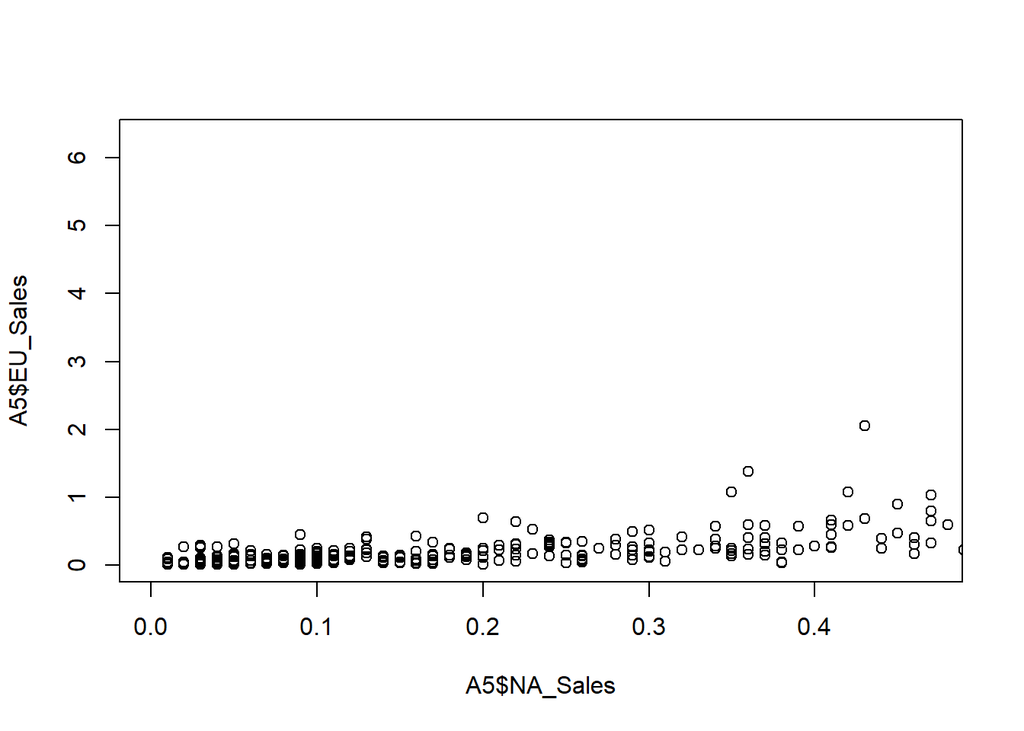

```r
#Created a new DataFrame that includes EU_Sales, the response variable, and NA_Sales and Platform, the explanatory variables.
A5 <- vgs %>%
  select(EU_Sales, NA_Sales, Platform) %>%
  filter(Platform == "PS4" | Platform == "XOne")
A5<-na.omit(A5)

#Making a scatter plot to compare EU_Sales with NA_Sales in order to visualize any trends.
plot(A5$EU_Sales~A5$NA_Sales, xlim=c(0,.47))
```

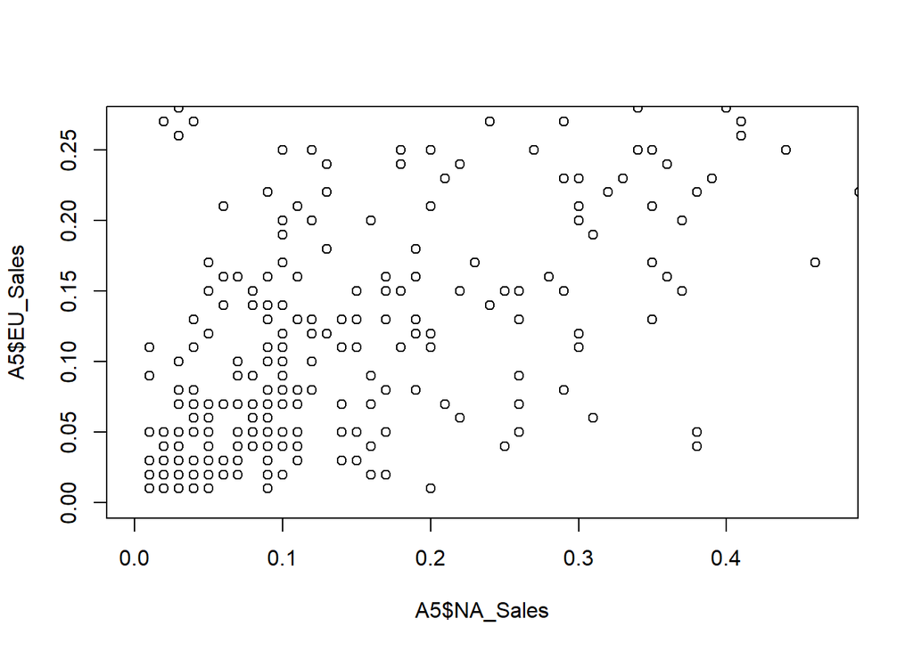

```r
plot(A5$EU_Sales~A5$NA_Sales, xlim=c(0,.47), ylim=c(0,.27)) #.27
```

```r
#Creating a DataFrame to analyze the correlation of EU_Sales and NA_Sales
corT <- data.frame(A5 %>%
  select_if(is.numeric) %>%
  cor())
corT
```

|  | EU_Sales | NA_Sales |
| --- | --- | --- |
| EU_Sales | 1.0000000 | 0.6872091 |
| NA_Sales | 0.6872091 | 1.0000000 |

The first and second graph in below section give visualizations on the residuals of the model. The first plot shows a good scatter among the residuals. Although not the ideal spread, it is enough to satisfy the condition of the residual independence. In order to check the normality of the residuals we will use a histogram and a qqnorm graph. The histogram shows a bimodal distribution and the qqnorm is relatively satisfactory, with some quirkiness at the ends. The bimodal distribution is not too severe, but is mostly satisfactory. But homoscedasticity of the residuals is a bit more questionable as there is a meaningful amount below the 0 line than above.

```r
#Creating a multi-linear regression model
Mlm <- model <- lm(EU_Sales ~ NA_Sales + Platform, data = A5)
summary(Mlm)
```

```
##
## Call:
## lm(formula = EU_Sales ~ NA_Sales + Platform, data = A5)
##
## Residuals:
##     Min      1Q  Median      3Q     Max
## -1.7768 -0.2002 -0.0241  0.1062  5.0079
##
## Coefficients:
##              Estimate Std. Error t value Pr(>|t|)
## (Intercept)   0.22654    0.03859   5.870 8.59e-09 ***
## NA_Sales      0.79071    0.03787  20.878  < 2e-16 ***
## PlatformXOne -0.33644    0.05202  -6.468 2.66e-10 ***
## ---
## Signif. codes:  0 '***' 0.001 '**' 0.01 '*' 0.05 '.' 0.1 ' ' 1
##
## Residual standard error: 0.544 on 439 degrees of freedom
## Multiple R-squared:  0.5182, Adjusted R-squared:  0.516
## F-statistic: 236.1 on 2 and 439 DF,  p-value: < 2.2e-16
```

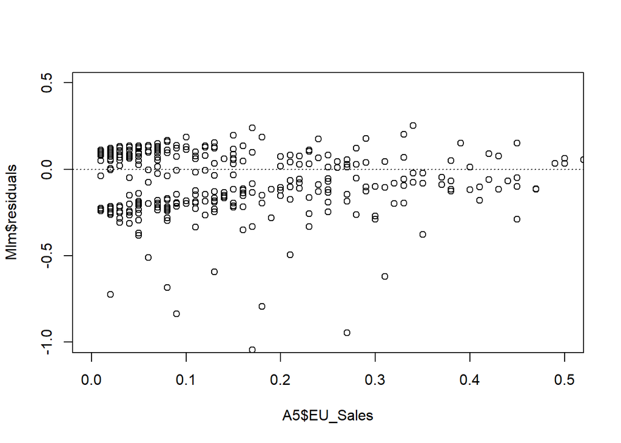

```r
#Plotting the residuals to visualize their variability
plot(Mlm$residuals ~ A5$EU_Sales,xlim=c(0,.5), ylim=c(-1,.5))
abline(h = 0, lty = 3)
```

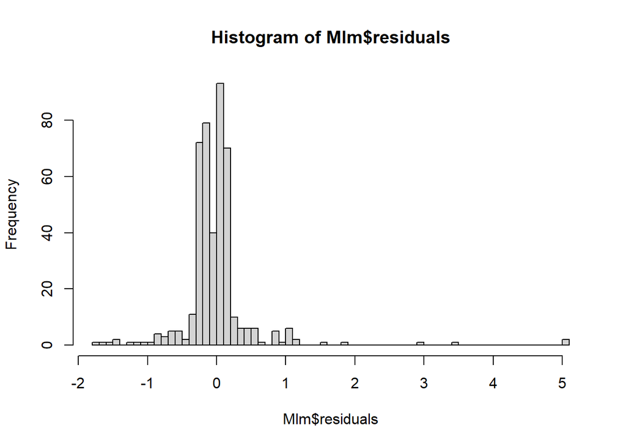

```r
hist(Mlm$residuals, breaks = 50)
```

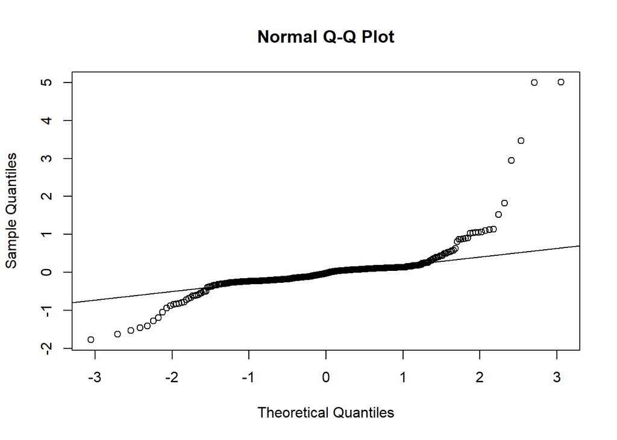

```r
qqnorm(Mlm$residuals)
qqline(Mlm$residuals)
```

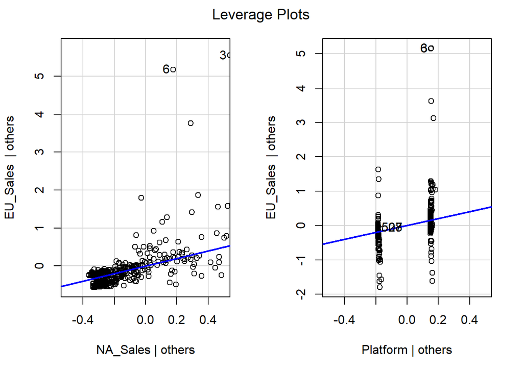

```r
leveragePlots(Mlm, xlim=c(-.5,.5))
```

```r
sigma(Mlm)/mean(A5$EU_Sales)
```

```
## [1] 1.265857
```

```r
anova(Mlm)
```

|  | Df | Sum Sq | Mean Sq | F value | Pr(>F) |
| --- | --- | --- | --- | --- | --- |
| NA_Sales | 1 | 127.32211 | 127.3221052 | 430.27490 | 4.056364e-67 |
| Platform | 1 | 12.37772 | 12.3777241 | 41.82953 | 2.659733e-10 |
| Residuals | 439 | 129.90394 | 0.2959087 | NA | NA |